# Exploring Minneapolis scooter and bike availability

Author

Dooly and Sohail

## What does a row mean?

[Scooter and Bike Availability 2024](https://opendata.minneapolismn.gov/datasets/c9e75387ca8343ab8a68a4f3446cd9bc_0/explore) contains hourly availability snapshots. Each record reports `NumberAvailable` for a company, poll time, closest street or trail segment, and neighborhood. We will check whether those fields uniquely identify records below.

These are availability counts, not trips or unique vehicle counts. A vehicle can appear in many consecutive snapshots. The table has no coordinates or geometry: `ClosestCenterlineID` is a join key for a separate street/trail dataset. The city notes that some centerline information is withheld for privacy or is unrecorded for certain vehicle statuses. Missing locations are not zero availability.

For a manageable first look, we use **July 15, 2024, midnight to midnight in America/Chicago**. This is a deliberately selected day, not a representative sample of the year. Download it from the repository root with `python3 analysis/download_availability.py`. All summaries and plots below use this one day unless explicitly labeled otherwise.

```r
library(dplyr)
library(ggplot2)
library(readr)
library(jsonlite)

# Support execution from either the analysis directory or repository root.
root <- if (file.exists("data/availability_metadata.json")) "." else ".."
meta <- fromJSON(file.path(root, "data/availability_metadata.json"))
raw <- read_csv(file.path(root, "data/availability_2024-07-15.csv"),
                col_types = cols(
                  PollTime = col_double(), CompanyName = col_character(),
                  NumberAvailable = col_double(), ClosestCenterlineID = col_character(),
                  ClosestCenterlineType = col_character(), Neighborhood = col_character(),
                  ObjectId = col_double()
                ))
stopifnot(nrow(raw) == meta$subset_rows, !anyDuplicated(raw$ObjectId))

# ArcGIS dates are milliseconds since the Unix epoch; the service declares UTC.
availability <- raw |>
  mutate(across(where(is.character), ~ na_if(na_if(trimws(.x), ""), "NULL")),
         poll_time = as.POSIXct(PollTime / 1000, origin = "1970-01-01", tz = "UTC"),
         local_hour = as.integer(format(poll_time, tz = "America/Chicago", format = "%H")))

tibble(scope = c("Full service", "Selected local day"),
       rows = c(meta$full_dataset_rows, nrow(raw)))
```

```
# A tibble: 2 × 2
  scope                 rows
  <chr>                <int>
1 Full service       5333169
2 Selected local day   26902
```

```r
glimpse(availability)
```

```
Rows: 26,902
Columns: 9
$ PollTime              <dbl> 1.72102e+12, 1.72102e+12, 1.72102e+12, 1.72102e+…
$ CompanyName           <chr> "Veo", "Veo", "Lime", "Lime", "Lime", "Veo Bikes…
$ NumberAvailable       <dbl> 6, 6, 9, 8, 8, 3, 3, 2, 3, 1, 3, 53, 1, 3, 3, 3,…
$ ClosestCenterlineID   <chr> "17871.00", "19902.00", "19781.00", NA, NA, "260…
$ ClosestCenterlineType <chr> "street", "street", "street", NA, NA, "street", …
$ Neighborhood          <chr> "North Loop", "Elliot Park", "Lyndale", "Lind - …
$ ObjectId              <dbl> 2558025, 2558031, 2558033, 2558034, 2558036, 255…
$ poll_time             <dttm> 2024-07-15 05:00:00, 2024-07-15 05:00:00, 2024-…
$ local_hour            <int> 0, 0, 0, 0, 0, 0, 0, 0, 0, 0, 0, 0, 0, 0, 0, 0, …
```

## Fields, missing values, and coverage

```r
# Retain centerline IDs as text, even when they look numeric.
meta$schema$fields |> select(name, type, nullable) |> knitr::kable()
```

| name | type | nullable |
| --- | --- | --- |
| PollTime | esriFieldTypeDate | TRUE |
| CompanyName | esriFieldTypeString | TRUE |
| NumberAvailable | esriFieldTypeInteger | TRUE |
| ClosestCenterlineID | esriFieldTypeString | TRUE |
| ClosestCenterlineType | esriFieldTypeString | TRUE |
| Neighborhood | esriFieldTypeString | TRUE |
| ObjectId | esriFieldTypeOID | FALSE |

```r
tibble(variable = names(raw),
       missing = vapply(availability[names(raw)], function(x) sum(is.na(x)), integer(1)),
       percent_missing = round(100 * missing / nrow(raw), 2)) |>
  knitr::kable()
```

| variable | missing | percent_missing |
| --- | --- | --- |
| PollTime | 0 | 0.00 |
| CompanyName | 0 | 0.00 |
| NumberAvailable | 0 | 0.00 |
| ClosestCenterlineID | 7364 | 27.37 |
| ClosestCenterlineType | 5756 | 21.40 |
| Neighborhood | 0 | 0.00 |
| ObjectId | 0 | 0.00 |

```r
availability |>
  summarise(first_poll_utc = min(poll_time), last_poll_utc = max(poll_time),
            distinct_poll_times = n_distinct(poll_time),
            companies = n_distinct(CompanyName, na.rm = TRUE),
            neighborhoods = n_distinct(Neighborhood, na.rm = TRUE),
            negative_counts = sum(NumberAvailable < 0, na.rm = TRUE),
            zero_counts = sum(NumberAvailable == 0, na.rm = TRUE)) |>
  knitr::kable()
```

| first_poll_utc | last_poll_utc | distinct_poll_times | companies | neighborhoods | negative_counts | zero_counts |
| --- | --- | --- | --- | --- | --- | --- |
| 2024-07-15 05:00:00 | 2024-07-16 04:00:00 | 24 | 4 | 87 | 0 | 0 |

```r
summary(availability$NumberAvailable)
```

```
   Min. 1st Qu.  Median    Mean 3rd Qu.    Max.
  1.000   3.000   3.000   5.359   3.000 340.000
```

```r
availability |> count(CompanyName, name = "records", sort = TRUE)
```

```
# A tibble: 4 × 2
  CompanyName records
  <chr>         <int>
1 Veo            7701
2 Lime           6905
3 Lime Bikes     6332
4 Veo Bikes      5964
```

```r
availability |> count(ClosestCenterlineType, name = "records", sort = TRUE)
```

```
# A tibble: 3 × 2
  ClosestCenterlineType records
  <chr>                   <int>
1 street                  19204
2 <NA>                     5756
3 trail                    1942
```

```r
# Inspect repeated candidate keys before assuming one row per segment/poll.
duplicate_keys <- availability |>
  count(PollTime, CompanyName, ClosestCenterlineID, ClosestCenterlineType,
        Neighborhood, name = "records") |>
  filter(records > 1)
tibble(repeated_candidate_keys = nrow(duplicate_keys),
       records_in_repeated_keys = sum(duplicate_keys$records))
```

```
# A tibble: 1 × 2
  repeated_candidate_keys records_in_repeated_keys
                    <int>                    <int>
1                       0                        0
```

```r
head(duplicate_keys, 10)
```

```
# A tibble: 0 × 6
# ℹ 6 variables: PollTime <dbl>, CompanyName <chr>, ClosestCenterlineID <chr>,
#   ClosestCenterlineType <chr>, Neighborhood <chr>, records <int>
```

On this selected day, 7364 records (27.4%) have no centerline ID after converting literal `"NULL"` values to missing. These records would need explicit accounting in a later map.

## How large are individual reported counts?

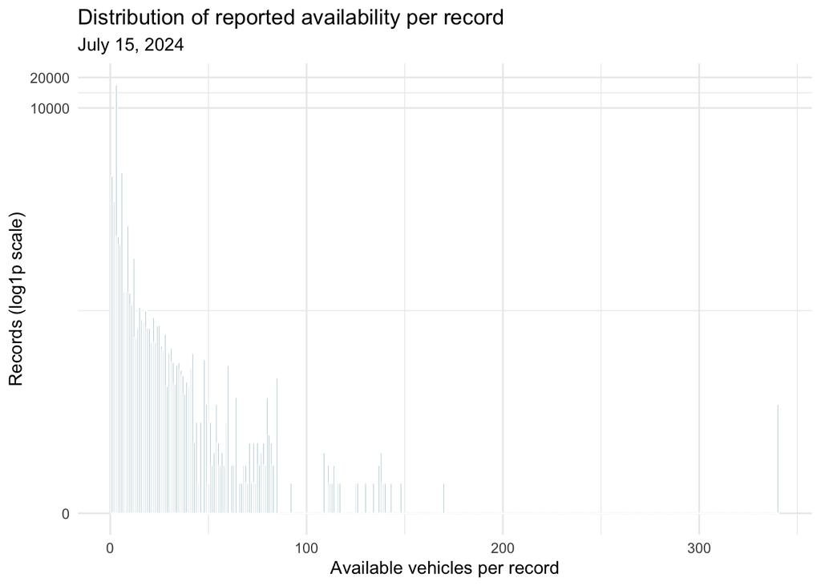

Figure 1: Distribution of counts per record on the selected day.

```r
ggplot(availability, aes(NumberAvailable)) +
  geom_histogram(binwidth = 1, boundary = -0.5, fill = "#247B91", color = "white") +
  scale_y_continuous(trans = "log1p") +
  labs(title = "Distribution of reported availability per record",
       subtitle = "July 15, 2024",
       x = "Available vehicles per record", y = "Records (log1p scale)") +
  theme_minimal()
```

Exactly 63.1% of records report **3** available vehicles. That concentration is worth investigating; the field documentation does not explain it, so we should not assume a cause. The maximum is 340 vehicles in one record, which could warrant inspecting the associated segment before mapping it.

## How does recorded availability change over the day?

```r
# Sum within a poll and company, never across hours to estimate unique vehicles.
# Preserve a missing total if any contributing count is unknown.
by_poll <- availability |>
  group_by(poll_time, CompanyName) |>
  summarise(available = if (anyNA(NumberAvailable)) NA_real_ else sum(NumberAvailable),
            records = n(), .groups = "drop")

by_poll |> group_by(CompanyName) |>
  summarise(observed_polls = n(), min_rows_per_poll = min(records),
            max_rows_per_poll = max(records), .groups = "drop") |>
  knitr::kable()
```

| CompanyName | observed_polls | min_rows_per_poll | max_rows_per_poll |
| --- | --- | --- | --- |
| Lime | 24 | 259 | 317 |
| Lime Bikes | 24 | 258 | 270 |
| Veo | 24 | 301 | 339 |
| Veo Bikes | 24 | 236 | 261 |

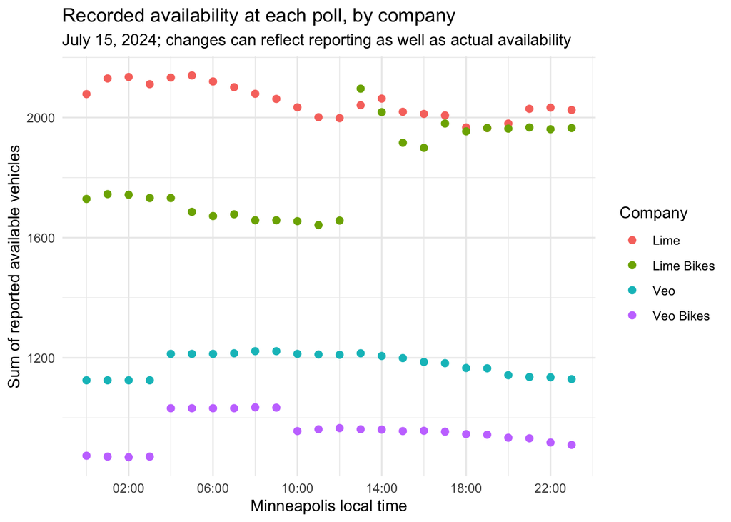

```r
# Points avoid implying continuous observation between polls or across gaps.
ggplot(by_poll, aes(poll_time, available, color = CompanyName)) +
  geom_point(size = 2) +
  scale_x_datetime(timezone = "America/Chicago", date_labels = "%H:%M", date_breaks = "4 hours") +
  labs(title = "Recorded availability at each poll, by company",
       subtitle = "July 15, 2024; changes can reflect reporting as well as actual availability",
       x = "Minneapolis local time", y = "Sum of reported available vehicles", color = "Company") +
  theme_minimal()
```

## Questions to investigate next

- Are polls present at every expected hour for each company? Missing polls should remain missing, rather than being replaced by zero.
- Do company patterns persist across other days and seasons?
- How often is the centerline ID missing, and does that vary by company?
- After joining the matching street and trail geometry, where is availability concentrated? A missing segment record does not establish zero availability.

There is no separate vehicle-type field, although company labels include “Lime Bikes” and “Veo Bikes”. Availability alone cannot measure ridership, demand, or equitable access. Neighborhood comparisons would also need a justified denominator and reporting-coverage checks.